# Sample Notebook - Simple Linear Regression: Hypothesis Tests and Confidence Intervals

# Loading and exploring the data

## Loading the data

In this sample notebook, I will be using the “birthweight” data from the Wooldridge package.

```r
library(wooldridge)
data('bwght')
?bwght
```

This data is from the 1989 linked National Mortality Detail files, which contains a census of infant births and deaths. Here we are looking at births in Pennsylvania in 1989.

Our goal is to examine the relationship between *bwght* (birth weight of the infant in ounces) and *cigs* (the average number of cigarettes smoked per day while pregnant).

You can find more information about the dataset here: https://rdrr.io/cran/wooldridge/man/bwght.html

### Packages needed

To group our data, we will be using the dplyr package, which is inside the `tidyverse` package. `tidyverse` also includes very useful packages like `ggplot`, which we will be using a lot. If you do not have `tidyverse` installed, use “install packages(‘tidyverse’)”.

[Here is a great summary](https://datacarpentry.org/R-genomics/04-dplyr.html) of common dplyr functions. It’s a very useful package!

```r
#install.packages('tidyverse')
library(tidyverse)
```

# Regression with a binary explanatory variable

## The Math

Simple linear regression can be used in cases where *x* is a binary variable (also called a dummy variable). Here, *x* can take on two values: zero and one. These two values are used to put each unit in the population into one of two groups represented by $x = 0$ and $x = 1$.

Let’s create a new variable in our data: $smoker = 1$ indicates that a person smokes, $smoker = 0$ indicates that a person does not.

```r
bwght <- bwght %>%
  mutate(smoker = case_when(cigs > 0 ~ 1,
                           cigs == 0 ~ 0 ))
```

Let’s check and make sure the new $smoker$ variable was added to the dataframe. To install the `kableExtra` package, remove the “#” from the front of that line of code.

```r
#install.packages('kableExtra')
library(kableExtra)
bwght_head <- head(bwght, n = 10)

kbl(
  bwght_head,
  caption = "First 10 Rows of Birthweight Dataframe",
  align = "lcc"
) |>
  kable_classic(full_width = FALSE) |>
  row_spec(0, bold = TRUE)
```

First 10 Rows of Birthweight Dataframe

| faminc | cigtax | cigprice | bwght | fatheduc | motheduc | parity | male | white | cigs | lbwght | bwghtlbs | packs | lfaminc | smoker |
| --- | --- | --- | --- | --- | --- | --- | --- | --- | --- | --- | --- | --- | --- | --- |
| 13.5 | 16.5 | 122.3 | 109 | 12 | 12 | 1 | 1 | 1 | 0 | 4.691348 | 6.8125 | 0 | 2.6026897 | 0 |
| 7.5 | 16.5 | 122.3 | 133 | 6 | 12 | 2 | 1 | 0 | 0 | 4.890349 | 8.3125 | 0 | 2.0149031 | 0 |
| 0.5 | 16.5 | 122.3 | 129 | NA | 12 | 2 | 0 | 0 | 0 | 4.859812 | 8.0625 | 0 | -0.6931472 | 0 |
| 15.5 | 16.5 | 122.3 | 126 | 12 | 12 | 2 | 1 | 0 | 0 | 4.836282 | 7.8750 | 0 | 2.7408400 | 0 |
| 27.5 | 16.5 | 122.3 | 134 | 14 | 12 | 2 | 1 | 1 | 0 | 4.897840 | 8.3750 | 0 | 3.3141861 | 0 |
| 7.5 | 16.5 | 122.3 | 118 | 12 | 14 | 6 | 1 | 0 | 0 | 4.770685 | 7.3750 | 0 | 2.0149031 | 0 |
| 65.0 | 16.5 | 122.3 | 140 | 16 | 14 | 2 | 0 | 1 | 0 | 4.941642 | 8.7500 | 0 | 4.1743875 | 0 |
| 27.5 | 16.5 | 122.3 | 86 | 12 | 14 | 2 | 0 | 0 | 0 | 4.454347 | 5.3750 | 0 | 3.3141861 | 0 |
| 27.5 | 16.5 | 122.3 | 121 | 12 | 17 | 2 | 0 | 1 | 0 | 4.795791 | 7.5625 | 0 | 3.3141861 | 0 |
| 37.5 | 16.5 | 122.3 | 129 | 16 | 18 | 2 | 0 | 1 | 0 | 4.859812 | 8.0625 | 0 | 3.6243410 | 0 |

In our dataset, we can add an *i* subscript, so $smoker_i$ indicates smoking status for a randomly drawn person *i*.

What does it mean to have a simple regression equation when *x* is binary?

We have our regression equation:

$y = \beta_0 + \beta_1 x + u$

$E(y | x) = \beta_0 + \beta_1 x + E(u|x) = \beta_0 + \beta_1 x$,

just like we’ve seen before. The only difference now is *x* can take on only two values. If we plug zero and one into the previous equation, we can see that:

$\beta_1 = E(y | x = 1) - E(y | x = 0)$.

The mechanics and assumptions of OLS do not change when *x* is binary. The definition of the $R^2$ is unchanged, residuals have zero mean, etc.

## The Interpretation

With continuous variables, you can see how one variable changes as you increase the value in the other variable. But with categorical variables, we’re dealing with groups in the data that you can’t incrementally increase. Because of this, we interpret categorical variables differently in regression.

$\beta_1$ is the difference in the average value of *y* between the subpopulation where $x = 1$ and where $x = 0$.

In the case of categorical variables, regression estimates the mean differences between these groups and determines whether the differences are statistically significant.

### Visualizing the relationship

Let’s take a look at a plot of our data. Box plots are a good way to look at differences between subpopulations.

Here we will use a box plot to look at the difference in *bwght* compared to whether someone is a smoker or not. We will be using `ggplot`

```r
theme_update(plot.title = element_text(hjust = 0.5))
```

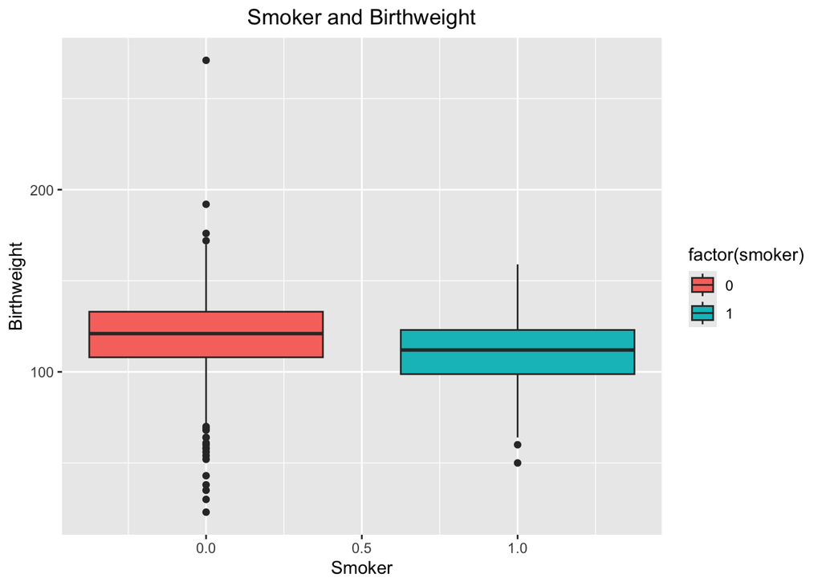

```r
ggplot(bwght, aes(x = smoker, y = bwght, fill = factor(smoker))) +
  geom_boxplot() +
  labs(y= "Birthweight", x = "Smoker") +
  ggtitle('Smoker and Birthweight')
```

As we see from the boxplot, it looks like there might be a difference. But how do we test if the difference is statistically significant? For that, we need to use a hypothesis test.

# Hypothesis Tests

A hypothesis test evaluates two mutually exclusive statements about the population and determines which statement the data support. These two statements are the hypotheses.

Our hypothesis test for this example is to test whether *birthweight* is the same, no matter the value for *smoker*, or whether there is a difference in *birthweight* depending on whether *smoker* = 1 or *smoker* = 0.

We can write this as:

$H_0: \mu_{smoker = 1} - \mu_{smoker = 0} = 0$ $H_1: \mu_{smoker = 1} - \mu_{smoker = 0} \neq 0$,

where each $\mu$ is the population mean birth weight for the indicated group.

To test this hypothesis, we need to find the *t*-statistic of the difference. The general formula for the *t*-statistic of the difference between means is:

$t = \frac{\bar{x_1} - \bar{x_2}}{SE_p}$,

where $SE_p$ is the pooled standard error.

Let’s start with the standard error in the denominator, and come back to the numerator.

## Standard Error of the Means

### Definition of Standard Error of the Mean

The standard error of the mean (SEM) is the variability of sample means in a sampling distribution of means.

Inferential statistics uses samples to estimate the properties of entire populations. The standard error of the mean involves fundamental concepts in inferential statistics—namely repeated sampling and sampling distributions. SEMs are a crucial component of that process.

Imagine you draw a random sample of 50 from a population, measure a property, and calculate the mean. Now, suppose you repeat that study many times. You repeatedly draw random samples of the same size, calculate the mean for each sample, and graph all the means on a histogram.

Then let’s say you do the same thing, but for a random sample of 100. You draw samples of the same size, calculate the mean for each sample, and graph all the means on a histogram.

These histograms represent the sampling distribution of the mean. There’s a different sampling distribution for each sample size: 50 and 100.

The variability of the sampling distributions is the standard error of the mean! More specifically, the SEM is the standard deviation of the sampling distribution.

The equation for the standard error of the mean is:

$SEM_N = \sqrt{\frac{\sigma^2}{N}} = \frac{\sigma}{\sqrt{N}}$,

- The numerator $\sigma^2$ is the variance and $\sigma$ is the sample standard deviation. This represents the variability present in the data.
- The denominator $\sqrt{N}$ is the square root of the sample size, and adjusts for the amount of data.

### Standard Error of the Difference between Means

We can use the standard error of the difference between means to test whether there is a statistically significant difference in *birthweight* when $smoker = 1$ vs. when $smoker = 0$.

To find the conventional standard error of the difference, we first combine the two group variances into a pooled variance estimate. This pooled standard error assumes that the population variances are equal (homoskedasticity):

$SE_p = \sqrt{s^2_{p}(\frac{1}{n_1} + \frac{1}{n_2})}$,

where

$s^2_{p} = \frac{(n_2 - 1)s^2_2 + (n_1 - 1)s^2_1}{n_2 + n_1 - 2}$

where $s_1^2$ is the sample variance of group one, $n_1$ is the number of observations in group one, $s_2^2$ is the sample variance of group two, and $n_2$ is the number of observations in group two.

Let’s break down what we need to do to find the standard error of the difference in means:

1. Find the sample variance of *birthweight* when *smoker* = 1.
2. Find the number of observations in our data where *smoker* = 1.
3. Find the sample variance of *birthweight* when *smoker* = 0.
4. Find the number of observations in our data where *smoker* = 0.
5. Plug those values into the equation for SEM.

#### Step 1

```r
smoker_true <- filter(bwght, smoker == 1)
var_smoker_true <- var(smoker_true$bwght)
var_smoker_true
```

```
## [1] 367.9264
```

#### Step 2

Next we need to find the number of observations where *smoker = 1*. We can use our filtered data to do so.

```r
n_smoker_true <- length(smoker_true$bwght)
n_smoker_true
```

```
## [1] 212
```

#### Step 3

```r
smoker_false <- filter(bwght, smoker == 0)
var_smoker_false <- var(smoker_false$bwght)
var_smoker_false
```

```
## [1] 410.8116
```

#### Step 4

Next we need to find the number of observations where *smoker = 0*. We can use our filtered data to do so.

```r
n_smoker_false <- length(smoker_false$bwght)
n_smoker_false
```

```
## [1] 1176
```

#### Step 5

Finally, we plug those values into the equation for the standard error of the difference. We are using the standard error of the pooled two-sample t-test, which assumes homoeskedasticity, or equal variance, between the two samples.

Homoskedasticity is used to derive the conventional OLS standard errors reported by `summary(lm(...))`. It is not required for OLS coefficient estimates to be unbiased, but it is required for those conventional standard errors to be valid. We will return to heteroskedasticity-robust standard errors later!

$SE = \sqrt{s^2_{p}(\frac{1}{n_1} + \frac{1}{n_2})}$,

where

$s^2_{p} = \frac{(n_2 - 1)s^2_2 + (n_1 - 1)s^2_1}{n_2 + n_1 - 2}$

```r
s2_pooled <- ((n_smoker_true - 1) * var_smoker_true + (n_smoker_false - 1) * var_smoker_false) / (n_smoker_true + n_smoker_false - 2)

SE_diff <- sqrt(s2_pooled * (1/n_smoker_true + 1/n_smoker_false))
SE_diff
```

```
## [1] 1.500258
```

### The *t*-statistic of the difference

Now that we have our standard error of the difference in means, we can return back to the numerator term of the *t*-statistic:

As we will be comparing the mean for *birthweight* when *smoker* = 1 and when *smoker* = 0, we will use the two-sample *t*-test:

$t = \frac{(\bar{x}_1 - \bar{x}_2)}{SE_{\bar{x}_1 - \bar{x}_2}}$,

where:

- $\bar{x}_1$ is the sample mean of *birthweight* where *smoker* = 1,
- $\bar{x}_2$ is the sample mean of *birthweight* where *smoker* = 0,
- $SE_{\bar{x}_1 - \bar{x}_2}$ is the standard error of the difference.

Let’s remind ourselves of our hypothesis test:

$H_0: \mu_1 - \mu_2 = 0$ $H_1: \mu_1 - \mu_2 \neq 0$

We are using the sample means $\bar{x}_1$ and $\bar{x}_2$ to test for the population means $\mu_1$ and $\mu_2$.

So is there a significant difference between the birthweight when *smoker* = 1 vs. when *smoker* = 0?

```r
mean_smoker_true <- mean(smoker_true$bwght)
mean_smoker_false <- mean(smoker_false$bwght)
cat("The mean birthweight when smoker = 1 is", mean_smoker_true, 'and the mean birthweight when smoker = 0 is', mean_smoker_false)
```

```
## The mean birthweight when smoker = 1 is 111.1462 and the mean birthweight when smoker = 0 is 120.0612
```

```r
mean_diff <- mean_smoker_true - mean_smoker_false
t_stat <- mean_diff / SE_diff

cat('The difference between the means is', mean_diff, '; the standard error of the difference is', SE_diff, '; the t-statistic of the difference is', t_stat)
```

```
## The difference between the means is -8.914998 ; the standard error of the difference is 1.500258 ; the t-statistic of the difference is -5.942312
```

The absolute value of the *t*-statistic is greater than the two-sided critical value from the *t*-distribution. Equivalently, its two-sided *p*-value is below 0.05. We therefore reject the null hypothesis of no population difference at the 5% significance level.

# Confidence Intervals

Another way to conduct inference is by constructing confidence intervals. A confidence interval uses the estimate, its standard error, and a critical value to quantify sampling uncertainty.

For a 95% confidence interval, we use the estimated difference in means plus or minus the standard error multiplied by the appropriate critical value. If we repeatedly drew samples and constructed intervals using this procedure, approximately 95% of those intervals would contain the true population difference.

```r
alpha <- .05
p <- 1 - .05/2
df <- n_smoker_false + n_smoker_true - 2
t_critical_value <- qt(p, df)

lower_ci_t <- mean_diff - t_critical_value * SE_diff
upper_ci_t <- mean_diff + t_critical_value * SE_diff

cat('The t-distribution critical value is', t_critical_value, 'and the 95% confidence interval for the difference in birthweight is', lower_ci_t, 'to', upper_ci_t)
```

```
## The t-distribution critical value is 1.961677 and the 95% confidence interval for the difference in birthweight is -11.85802 to -5.971977
```

The confidence interval does not include zero, so a two-sided test rejects the null hypothesis of no population difference at the 5% significance level.

We could also use the critical value from the normal distribution for an approximation that does not take the degrees of freedom from our data into account. If we do that, we get the following confidence interval:

```r
lower_ci <- mean_diff - 1.96 * SE_diff
upper_ci <- mean_diff + 1.96 * SE_diff

cat('Using the normal critical value of 1.96, the approximate 95% confidence interval for the difference in birthweight is', lower_ci, 'to', upper_ci)
```

```
## Using the normal critical value of 1.96, the approximate 95% confidence interval for the difference in birthweight is -11.8555 to -5.974493
```

As you can see, they’re quite similar!

## Doing it the shorter way

Of course, this whole calculating the *t*-statistic and confidence intervals by hand was a lot of work. But there’s a shorter and easier way!

To make reporting your results easier, use the following steps:

### How to use reporting.R in your .Rmd

#### 1. Put the file in the right place

- Download or copy reporting.R
- Save it in the same folder as your .Rmd file (your lab/notebook)

Your folder should look like:

week-03/ week-03.Rmd reporting.R

#### 2. Load the functions at the top of your .Rmd

Add this code chunk near the top (after your setup chunk):

```r
source("reporting.R")
```

If you get an error like *“cannot open file reporting.R”*, it means the file is not in the same folder as your `.Rmd`.

You also need to make sure you have all the necessary packages loaded. Along with `tidyverse`, which we loaded above, you will need `knitr` and `kableExtra`.

```r
#install.packages('knitr')
#install.packages('kableExtra')
library(knitr)
library(kableExtra)
```

#### 3. Fit your model

Example:

```r
mod1 <- lm(bwght ~ smoker, data = bwght)

#For a simple summary, remove the "#" in front of the code line below
#summary(mod1)
```

#### 4. Print an accessible model summary table

**Important:** the chunk that prints the table must include `results='asis'`.

**Option A: Simple table (recommended)**

```r
mk_coeftab(
  mod1,
  mode = "simple",
  term_labels = c(
    smoker = "Smoker (1 = yes, 0 = no)"
  ),
  caption = "Model: Birthweight on Smoking Status"
)
```

Model: Birthweight on Smoking Status

| Term | Estimate | Std. Error | p value |
| --- | --- | --- | --- |
| Intercept | 120.061 | 0.586 | <0.001 |
| Smoker (1 = yes, 0 = no) | -8.915 | 1.500 | <0.001 |

**Option B: Full table (adds t/z and confidence intervals)**

```r
mk_coeftab(
  mod1,
  mode = "full",
  term_labels = c(
    smoker = "Smoker (1 = yes, 0 = no)"
  ),
  caption = "Model (full): Birthweight on Smoking Status"
)
```

Model (full): Birthweight on Smoking Status

| Term | Estimate | Std. Error | t/z value | p value | 95% CI |
| --- | --- | --- | --- | --- | --- |
| Intercept | 120.061 | 0.586 | 204.77 | <0.001 | 118.911 to 121.211 |
| Smoker (1 = yes, 0 = no) | -8.915 | 1.500 | -5.94 | <0.001 | -11.858 to -5.972 |

#### 5) Compare multiple models (fit statistics)

Fit two models, then compare:

```r
mod1 <- lm(bwght ~ smoker, data = bwght)
mod2 <- lm(bwght ~ log(faminc), data = bwght)
```

```r
mk_fit(
  `Model 1: birthweight ~ smoker` = mod1,
  `Model 2: birthweight ~ ln(family income)` = mod2,
  caption = "Model comparison"
)
```

Model comparison

| Model | R² | Adj. R² | AIC | BIC | Residual SE |
| --- | --- | --- | --- | --- | --- |
| Model 1: birthweight ~ smoker | 0.025 | 0.024 | 12273.9 | 12289.6 | 20.107 |
| Model 2: birthweight ~ ln(family income) | 0.011 | 0.011 | 12293.2 | 12308.9 | 20.247 |

Going back to the simple regression results, let’s take a look at the coefficients only:

```r
mk_coeftab(
  mod1,
  mode = "simple",
  term_labels = c(
    smoker = "Smoker (1 = yes, 0 = no)"
  ),
  caption = "Model: Birthweight on Smoking Status"
)
```

Model: Birthweight on Smoking Status

| Term | Estimate | Std. Error | p value |
| --- | --- | --- | --- |
| Intercept | 120.061 | 0.586 | <0.001 |
| Smoker (1 = yes, 0 = no) | -8.915 | 1.500 | <0.001 |

What do you see? What is the intercept equal to, and what is the coefficient on *smoker* equal to? What about the standard error on *smoker*, what do you see there?

The intercept is equal to the mean birth weight when *smoker* = 0, the reference group. The coefficient on *smoker* equals the smoker mean minus the nonsmoker mean. Under the equal-variance assumption used above, the conventional standard error and *t*-statistic also match the pooled difference-in-means calculations.

We can also find our confidence intervals:

```r
confint(mod1)
```

```
##                 2.5 %     97.5 %
## (Intercept) 118.91104 121.211406
## smoker      -11.85802  -5.971977
```

Those look familiar as well, as they are the same ones we found when using the t-distribution to find our confidence interval. Awesome!

Quick note: if we were to calculate the standard error of the difference “by hand” using the estimates in the regressions, we would not have to divide by *n* because our estimators have already taken care of this!

# Repeated Samples to Assess Regression Coefficients

We want to remember that our estimated regression coefficients are random variables, because they depend on the sample that we used to estimate them. If we had a different sample, we’d have estimated different values for $\hat{\beta_0}$ and $\hat{\beta_1}$.

So in order to conduct a hypothesis test on an individual regression coefficient $\beta_i$, we need to use the distribution of its estimator $\hat{\beta_i}$:

*The mean of the distribution of the sample regression coefficient is the population regression coefficient $\beta_i$.* The standard deviation of the distribution of the sample regression coefficient is $\sigma_{\hat{\beta_i}}$. Because we do not know the population standard deviation we must estimate $\sigma_{\hat{\beta_i}}$ with the sample standard deviation $\hat{\sigma}_{\hat{\beta_i}}$. *If the regression errors are normally distributed, the OLS coefficient has an exact normal sampling distribution. Without normal errors, the sampling distribution is approximately normal in sufficiently large samples under the usual regularity conditions.

Let’s construct a number of random subsamples from our data and re-calculate $\hat{\beta_0}$ and $\hat{\beta_1}$. We’ll then take the mean of these calculated values and see how close they are to our original regression coefficient estimates.

A random subsample can be constructed using the function sample().

```r
N <- nrow(bwght) # returns the number of observations in the dataset
Sub_S <- 50         # desired number of subsamples
S <- 60         # desired sample size to draw from the dataset in each subsample

sumb1 <- 0 # here is where we will add up all the estimated beta coefficients

for (i in 1:Sub_S){   # a loop over the number of subsamples
  set.seed(3*i)   # a different seed for each subsample
  subsample <- bwght[sample(1:N, size = S, replace = TRUE), ] #drawing the random sample of size S from the bwght dataset
  mod2 <- lm(bwght ~ smoker, data = subsample) #estimating the model
  #sum b1 for all subsamples:
  sumb1 <- sumb1 + coef(mod2)[[2]] #adding the beta coefficient to our total
}
print(sumb1/Sub_S, digits = 3) #printing out the average value of the beta 1 coefficients from the 50 models estimated from the 50 subsamples
```

```
## [1] -8.64
```

```r
N <- nrow(bwght) # returns the number of observations in the dataset
Sub_S <- 50         # desired number of subsamples
S <- 60         # desired sample size to draw from the dataset in each subsample

sumb0 <- 0 # here is where we will add up all the estimated beta coefficients

for (i in 1:Sub_S){   # a loop over the number of subsamples
  set.seed(3*i)   # a different seed for each subsample
  subsample <- bwght[sample(1:N, size = S, replace = TRUE), ] #drawing the random sample of size S from the bwght dataset
  mod2 <- lm(bwght ~ smoker, data = subsample) #estimating the model
  #sum b0 for all subsamples:
  sumb0 <- sumb0 + coef(mod2)[[1]] #adding the beta coefficient to our total
}
print(sumb0/Sub_S, digits = 3) #printing out the average value of the beta 0 coefficients from the 50 models estimated from the 50 subsamples
```

```
## [1] 119
```

We see that we get averages of 50 estimates of $\hat{\beta_0}$ and $\hat{\beta_1}$ that are pretty close to what we estimated from our data. Try changing the number of subsamples and the sample size to draw in each subsample, and see what happens to the averages of the estimates!

# A Monte Carlo Simulation

A Monte Carlo simulation generates random values for the dependent variable when the regression coefficients and the distribution of the random term are given.

Besides our point estimates themselves, we want to know how close our estimates are to the true values of $\beta_i$, or its “accuracy” or “precision.” An estimator is a function of random variables, and is therefore itself a random variable.

The properties of an estimator are fully described by its probability distribution (the sampling distribution). We can use this sampling distribution to perform tests against hypotheses. We’re usually especially interested in some moments of the sampling distribution, like the mean and the variance. Sometimes, especially for finite (small) samples, its difficult to calculate the sampling distribution from the econometric model, and the Monte Carlo simulation method can be used to get more information about the sampling distribution. It can also be used to get more information about the “quality” of an estimator.

“Monte Carlo” refers to processes where information is approximated by generated random realizations of a stochastic (random) process and averaging them in some way.

A Monte Carlo experiment involves the following steps:

1. Assume values for the exogenous parts of the model, or draw them from their distribution function
2. Draw a (pseudo) random sample of size *N* for the error term in the statistical model from their respective probability distribution functions
3. Calculate the endogenous parts of the statistical model
4. Calculate the value (in our case, the regression estimators and standard errors) that we are interested in
5. Replicate steps 1 to 4 *R* times
6. Examine the empirical distribution of the *R* values

## OLS Example

The goal of the example below is to check the distribution of the independent variable in our model:

$bwght_i = \beta_0 + \beta_1 smoker_i + e_i$

Remember that $smoker$ can take the value $0$ or $1$.

So here we have a bivariate OLS model, with $e_i \sim N(0, \sigma^2)$. The stochastic (random) element in the model is our error term $e_i$; the exogenous bit is $smoker_i$, and is either fixed or stochastic.

Assuming values and plugging them in for the true regression parameters, we can simulate the endogenous variable $bwght_i$. The values of interest are then the least squares estimates $\hat{\beta_0}$ and $\hat{\beta_1}$ that we get in the simulated data set.

The core of Monte Carlo experiments is the random number generator. A random number generator produces a sequence of numbers that are draws from some specified identically and independently distributed random variable.

In practice, this is an algorithm that produces a sequence of pseudo random numbers, and these numbers aren’t really random since the algorithm describes the deterministic relationship between the numbers. However, with a good generator, they still pass usual independence tests.

There is a really important thing to remember about Monte Carlos: we have to **completely** specify the Statistical Model (Data Generating Process). This means that we have to assume the deterministic parts of the model, the form of the model, and the exact parameters of the distribution of the random error term and the distribution of exogenous variables.

This means that the results of our Monte Carlo experiment apply only to our assumptions made, so this results in a is a loss of general applicability to other situations where these assumptions have not been made.

```r
N <- 100 # size of sample
x1 <- 0 # smoker = 0
x2 <- 1 # smoker = 1
b0 <- 120 # approximate estimate of beta 0 from regression
b1 <- -9 # approximate estimate of beta 1 from regression
mu = 0 # mean of the error term
var <- 1000 # variance
sigma <- sqrt(var) # standard deviation

yhat1 <- b0 + b1 * x1  # first predicted value of y
yhat2 <- b0 + b1 * x2 # second predicted value of y
```

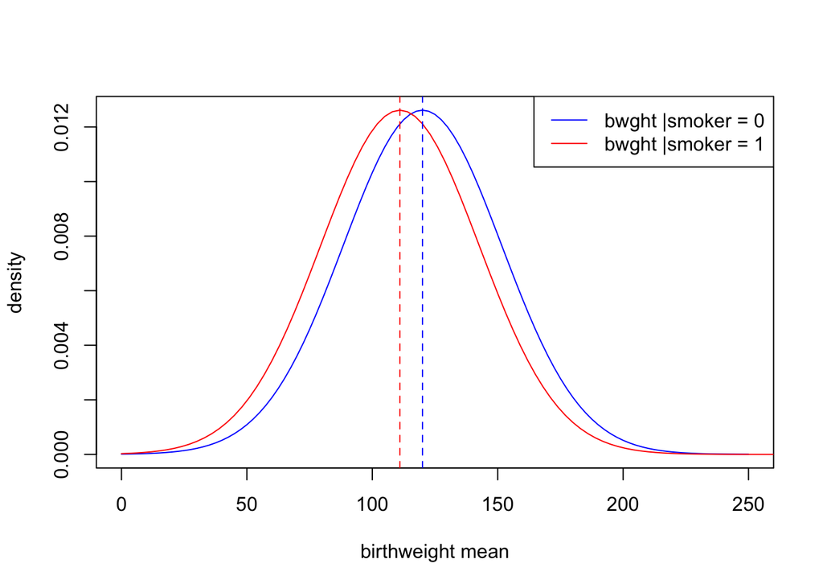

```r
# plotting the probability density function
curve(dnorm(x, mean = yhat1, sd = sigma), 0, 250, col="blue", xlab = 'birthweight mean', ylab = 'density')
curve(dnorm(x, yhat2, sigma), 0, 300, add = TRUE, col="red")
abline(v = yhat1, col="blue", lty = 2)
abline(v = yhat2, col="red", lty = 2)
legend("topright", legend=c("bwght |smoker = 0",
                            "bwght |smoker = 1"), lty=1,
       col=c("blue", "red"))
```

We see now that we have a theoretical (true) probability distribution of birthweight, given whether $smoker = 0$ or $smoker = 1$.

Let’s calculate the variance of $\hat{\beta_1}$:

$var(\hat{\beta_1}) = \frac{\sigma^2}{\sum_{i=1}^{N}(x_i - \bar{x})^2}$

and plot the density function.

```r
N <- 50 # size of sample
x1 <- 0 # smoker = 0
x2 <- 1 # smoker = 1
b0 <- 120 # approximate estimate of beta 0
b1 <- -9 # approximate estimate of beta 1
mu <- 0 # mean of the error term
var <- 1000 # variance
sigma <- sqrt(var) # standard deviation

x <- c(rep(x1, N/2), rep(x2,N/2)) #rep replicates the values in x
# each value of x (0 or 1) is being replicated N/2 times

xbar <- mean(x) # mean of x
sumx2 <- sum((x-xbar)^2) # the variance denominator
varb1 <- sigma^2 / sumx2 # variance of beta 1
sdb1 <- sqrt(varb1) #standard deviation of beta 1 (square root of variance)
leftlim <- b1 - 3 * sdb1 #left limit for curve
rightlim <- b1 + 3 * sdb1 #right limit for curve
```

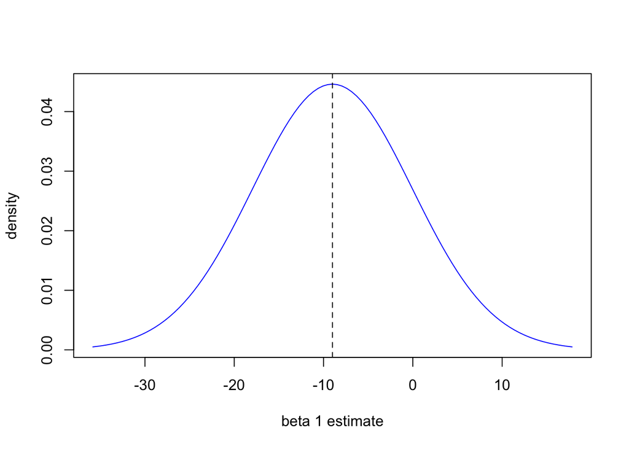

```r
curve(dnorm(x, mean = b1, sd = sdb1), leftlim, rightlim, col = 'blue', xlab = 'beta 1 estimate', ylab = 'density')
abline(v = b1, lty=2)
```

Here is the theoretical (true) probability density function of $\hat{\beta_1}$.

```r
N <- length(bwght$smoker)
var <- 1000
sigma <- sqrt(var_smoker_true)
x <- bwght$smoker
nrsim <- 10000
b0 <- 120
b1 <- -9

vb1 <- numeric(nrsim) #stores the estimates of b1

for (i in 1:nrsim){
  set.seed(12345+10*i) #makes the seed random
  y <- b0 + b1 * x + rnorm(N, mean=0, sd=sigma)
  mod4 <- lm(y ~ x)
  vb1[i] <- coef(mod4)[[2]] #adds the estimate of b1 to vb1
}

mb1 <- mean(vb1) #gets the means of vb1
seb1 <- sd(vb1) #gets the standard error of vb1
```

Let’s take a look at the mean of the simulated coefficient estimates and the standard deviation of their sampling distribution. That standard deviation is the Monte Carlo estimate of the coefficient’s standard error:

```r
cat('The mean of the coefficients from our ', nrsim, ' simulations is ', mb1)
```

```
## The mean of the coefficients from our  10000  simulations is  -8.991026
```

```r
cat('The standard deviation of the coefficients from our ', nrsim, ' simulations is', seb1)
```

```
## The standard deviation of the coefficients from our  10000  simulations is 1.425932
```

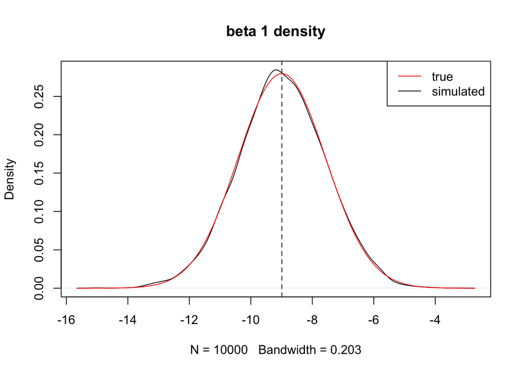

```r
plot(density(vb1), main = 'beta 1 density')
curve(dnorm(x, mb1, seb1), col="red", add=TRUE)
abline(v = mb1, lty=2)
legend("topright", legend=c("true", "simulated"),
       lty=1, col=c("red", "black"))
```

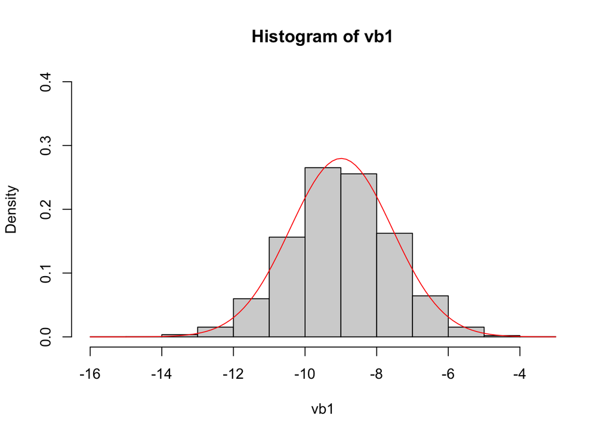

```r
hist(vb1, prob=TRUE, ylim=c(0,.4))
curve(dnorm(x, mean=mb1, sd=seb1), col="red", add=TRUE)
```

We see that the value of $\hat{\beta_1}$ from our Monte Carlo simulation isn’t too far off from what we initially estimated with the data. The graphs show the simulated distributions and the theoretical true distributions, and they look like they line up quite nicely.

# Estimated Variances and Covariance of Regression Coefficients

Speaking of variances, we will often want to access the variances and covariances from our models. R helpfully stores them in a matrix for us, which we can access using `vcov`.

Let’s take a look. For an easy way to code this, remove the ‘#’ in front of `vcov(mod1)`.

```r
#vcov(mod1)
```

For an accessible version of the variance-covariance matrix using the `reporting.R` notebook, use the following instructions.

## Instructions for using `reporting.R` for Variance-Covariance Matrices

### 1. Put reporting.R in the same folder as your .Rmd.

Your folder should look like:

week3 -Sample_Notebook.Rmd -reporting.R

### 2. Load the reporting script near the top of your .Rmd notebook

```r
source("reporting.R")
```

### 3. Fit your model

```r
mod1 <- lm(bwght ~ smoker, data = bwght)
```

### 4. Print the variance–covariance matrix (accessible table):

Use a chunk with `results='asis'`:

**Most readable (recommended):**

```r
mk_vcov_table(
  mod1,
  format = "long",
  term_labels = c(smoker = "Smoker (1 = Yes, 0 = No)"),
  caption = "Variance–covariance table for model coefficients"
)
```

Variance–covariance table for model coefficients

| Term 1 | Term 2 | Covariance |
| --- | --- | --- |
| Intercept | Intercept | 0.3438 |
| Intercept | Smoker (1 = Yes, 0 = No) | -0.3438 |
| Smoker (1 = Yes, 0 = No) | Intercept | -0.3438 |
| Smoker (1 = Yes, 0 = No) | Smoker (1 = Yes, 0 = No) | 2.2508 |

**Classic square matrix (harder to read, but standard):**

```r
mk_vcov_table(mod1, format = "matrix")
```

Variance–covariance matrix of coefficient estimates

| Term | Intercept | smoker |
| --- | --- | --- |
| Intercept | 0.3438 | -0.3438 |
| smoker | -0.3438 | 2.2508 |

**Correlation matrix of estimates (often easier to interpret):**

```r
mk_vcov_table(mod1, format = "cor")
```

Correlation matrix of coefficient estimates

| Term | Intercept | smoker |
| --- | --- | --- |
| Intercept | 1.0000 | -0.3908 |
| smoker | -0.3908 | 1.0000 |

Linear algebra isn’t a prerequisite for this class, and we won’t go too far into regression in matrix form. However, we will be using some of this for heteroskedasticity and panel data, so I wanted to show you what it looked like when we had a simple, one-variable regression!

# Summary

Hypothesis testing is a statistical procedure that allows you to use a sample to draw conclusions about an entire population. It evaluates two mutually exclusive statements about the population and determines which statement the data support.

The hypothesis testing procedure is as follows:

1. Draw a sample from the population of interest.
2. State your null and alternative hypotheses about the population. Usually, the null is that there is no effect ($\beta_1 = 0$), and the alternative is that there *is* an effect ($\beta_1 \neq 0$).
3. Determine your significance level $\alpha$. The significance level defines how strong the sample evidence must be to conclude an effect exists in the population. In economics, $\alpha$ is usually set to 0.05, which signifies a 5% risk of deciding an effect exists when it does not.
4. Run a regression to determine the coefficient (the estimated value $\hat{\beta_1}$) and the standard error.
5. Look at the *t*-statistic and *p*-value of the coefficient. The difference between the estimator $\hat{\beta_1}$ and the hypothesized value is in the numerator of the *t*-statistic; the standard error is in the denominator. For a two-sided test, reject the null when the absolute value of the *t*-statistic is greater than the critical value.
6. Look at the *p*-value associated with the *t*-statistic. The *p*-value is the probability, assuming the null hypothesis is true, of obtaining a test statistic at least as extreme as the one observed. Lower *p*-values represent stronger evidence against the null. If the *p*-value is less than or equal to $\alpha$, reject the null hypothesis.
7. Look at the confidence interval. Across repeated samples, 95% of intervals constructed using a valid 95% confidence-interval procedure would contain the true population value. If 0 is not included in the realized interval, reject the null hypothesis $H_0:\beta_1=0$ in the corresponding two-sided test at the 5% significance level.
8. Simulation procedures such as Monte Carlo experiments can help us study the finite-sample behavior of estimators and tests under a fully specified data-generating process. Their conclusions apply to the assumptions built into that simulation.